# Sampling Distributions - Difference in Means

### Confidence Interval - Difference In Means

Here you will look through the example from the last video, but you will also go a couple of steps further into what might actually be going on with this data.

```python
import pandas as pd
import numpy as np
import matplotlib.pyplot as plt

%matplotlib inline
np.random.seed(42)

full_data = pd.read_csv('coffee_dataset.csv')
sample_data = full_data.sample(200)
```

```python
sample_data.head()
```

|  | user_id | age | drinks_coffee | height |
| --- | --- | --- | --- | --- |
| 2402 | 2874 | <21 | True | 64.357154 |
| 2864 | 3670 | >=21 | True | 66.859636 |
| 2167 | 7441 | <21 | False | 66.659561 |
| 507 | 2781 | >=21 | True | 70.166241 |
| 1817 | 2875 | >=21 | True | 71.369120 |

```python
diffs1 = []
for _ in range(10000):
    bs = sample_data.sample(200, replace=True)
    cy = bs[bs["drinks_coffee"] == True]
    cn = bs[bs["drinks_coffee"] == False]
    cy_hm = cy["height"].mean()
    cn_hm = cn["height"].mean()
    diff = cy_hm - cn_hm
    diffs1.append(diff)
```

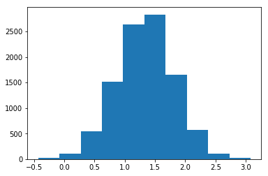

```python
plt.hist(diffs1);
```

```python
np.percentile(diffs1, 2.5), np.percentile(diffs1, 97.5)
```

```
(0.39656867909086274, 2.2409418186017551)
```

```python
diffs2 = []
for _ in range(10000):
    bs = sample_data.sample(200, replace=True)
    younger = bs[bs["age"] == "<21"]
    older = bs[bs["age"] == ">=21"]
    y_hm = younger["height"].mean()
    o_hm = older["height"].mean()
    diff = o_hm - y_hm
    diffs2.append(diff)
```

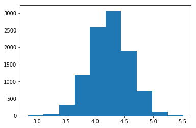

```python
plt.hist(diffs2);
```

```python
np.percentile(diffs2, 2.5), np.percentile(diffs2, 97.5)
```

```
(3.576119649609014, 4.8937985328397238)
```

`3.` For 10,000 iterations bootstrap your sample data, compute the difference in the average height for coffee drinkers and the average height for non-coffee drinkers for individuals under 21 years old. Using your sampling distribution, build a 95% confidence interval. Use your interval to start answering question 2 below.

```python
diffs3 = []
for _ in range(10000):
    bs = sample_data.sample(200, replace=True)
    younger = bs[bs["age"] == "<21"]
    cy = younger[younger["drinks_coffee"] == True]
    cn = younger[younger["drinks_coffee"] == False]
    cy_hm = cy["height"].mean()
    cn_hm = cn["height"].mean()
    diff = cn_hm - cy_hm
    diffs3.append(diff)
```

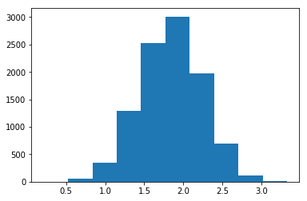

```python
plt.hist(diffs3);
```

```python
np.percentile(diffs3, 2.5), np.percentile(diffs3, 97.5)
```

```
(1.0604833025073632, 2.5932349683121609)
```

`4.` For 10,000 iterations bootstrap your sample data, compute the difference in the average height for coffee drinkers and the average height for non-coffee drinkers for individuals under 21 years old. Using your sampling distribution, build a 95% confidence interval. Use your interval to finish answering the second quiz question below. As well as the following questions.

*(i'm assuming they mean 21 and over for this one...)*

```python
diffs4 = []
for _ in range(10000):
    bs = sample_data.sample(200, replace=True)
    older = bs[bs["age"] == ">=21"]
    cy = older[older["drinks_coffee"] == True]
    cn = older[older["drinks_coffee"] == False]
    cy_hm = cy["height"].mean()
    cn_hm = cn["height"].mean()
    diff = cn_hm - cy_hm
    diffs4.append(diff)

print("done")
```

```
done
```

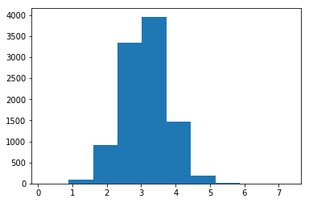

```python
plt.hist(diffs4);
```

```python
np.percentile(diffs4, 2.5), np.percentile(diffs4, 97.5)
```

```
(1.8280535113036145, 4.3961104980494934)
```